# Tarea 3 - Algunas Distribuciones Importantes de Probabilidad

Héctor Hibran Tapia Fernández - A01661114

2024-08-09

## Pregunta 1

1. Graficar una distribución Normal con media 10, y desviación estándar 2.

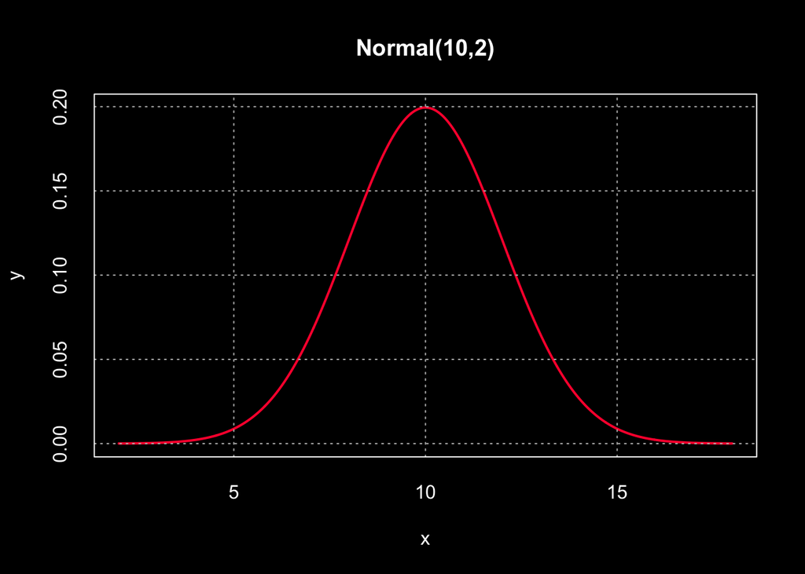

```r
par(bg = "black", col.axis = "white", col.lab = "white", col.main = "white", col.sub = "white")

mu = 10
sigma = 2
x = seq(mu - 4*sigma, mu + 4*sigma, 0.01)
y = dnorm(x, mu, sigma)

plot(x, y, type = "l", col = '#FF073A', lwd = 2, main = "Normal(10,2)",
     col.main = "white", col.lab = "white", col.axis = "white", col.sub = "white")

grid(col = "gray", lty = "dotted")
box(col = "white")
```

## Pregunta 2

2. Graficar una distribución T Student con grados de libertad v = 12

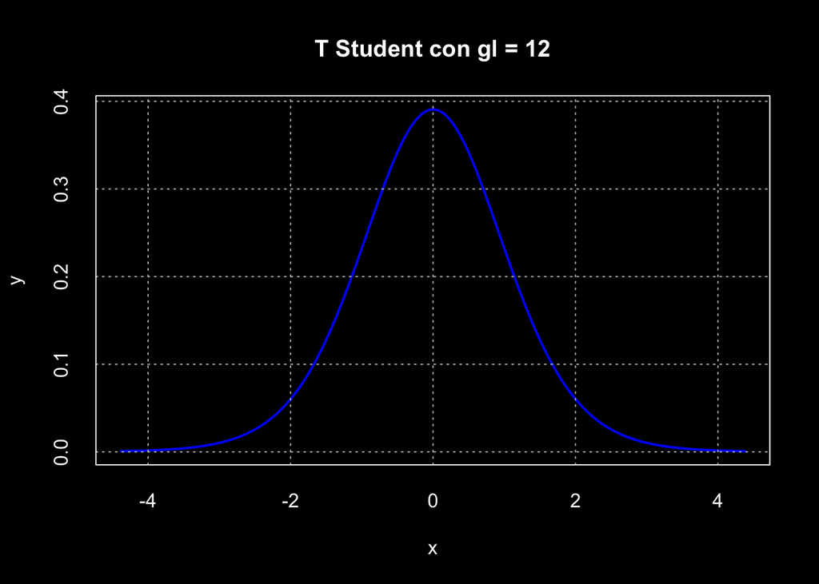

```r
par(bg = "black", col.axis = "white", col.lab = "white", col.main = "white", col.sub = "white")

gl = 12
sigma = sqrt(gl/(gl-2))
x = seq( -4*sigma, 4*sigma, 0.01)
y = dt(x,gl)

plot(x, y, type = "l", col = 'blue', lwd = 2, main = "T Student con gl = 12",
     col.main = "white", col.lab = "white", col.axis = "white", col.sub = "white")

grid(col = "gray", lty = "dotted")
box(col = "white")
```

## Pregunta 3

3. Gráfique la distribución Chi-cuadrada con 8 grados de libertad.

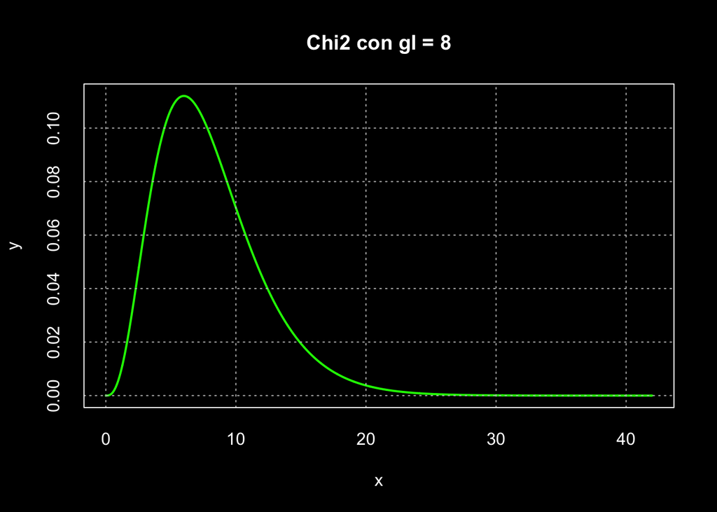

```r
par(bg = "black", col.axis = "white", col.lab = "white", col.main = "white", col.sub = "white")

gl = 8
sigma = sqrt(2*gl)
x = seq( 0, mu + 8*sigma, 0.01)
y = dchisq(x,gl)

plot(x, y, type = "l", col = 'green', lwd = 2, main = "Chi2 con gl = 8",
     col.main = "white", col.lab = "white", col.axis = "white", col.sub = "white")

grid(col = "gray", lty = "dotted")
box(col = "white")
```

## Pregunta 4

4. Graficar una distribución F con v1 = 9, v2 = 13

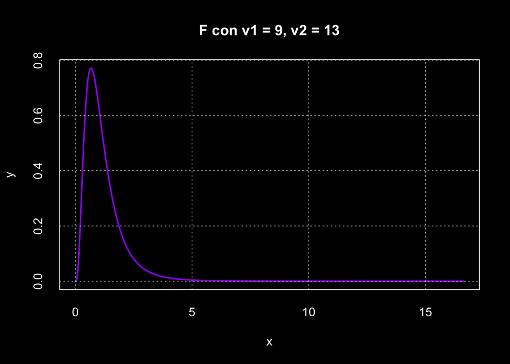

```r
par(bg = "black", col.axis = "white", col.lab = "white", col.main = "white", col.sub = "white")

v1 = 9
v2 = 13
sigma = sqrt(2)*v2*sqrt(v2+v1-2)/(sqrt(v2-4)*(v2-2)*sqrt(v1))
x = seq( 0, mu + 8*sigma, 0.01)
y = df(x,v1, v2)

plot(x, y, type = "l", col = 'purple', lwd = 2, main = "F con v1 = 9, v2 = 13",
     col.main = "white", col.lab = "white", col.axis = "white", col.sub = "white")

grid(col = "gray", lty = "dotted")
box(col = "white")
```

## Pregunta 5

5. Si Z es una variable aleatoria que se distribuye normalmente con media 0 y desviación estándar 1, hallar los procedimientos de:
1. P(Z > 0.7) = 0.2419637
2. P(Z < 0.7) = 0.7580363
3. P(Z = 0.7) = 0
4. Hallar el valor de Z que tiene al 45% de los demás valores inferiores a ese valor.

```r
P_Z_mayor_que_0.7 <- 1 - pnorm(0.7)
P_Z_mayor_que_0.7
```

```
## [1] 0.2419637
```

```r
P_Z_menor_que_0.7 <- pnorm(0.7)
P_Z_menor_que_0.7
```

```
## [1] 0.7580363
```

```r
P_Z_igual_a_0.7 <- 0
P_Z_igual_a_0.7
```

```
## [1] 0
```

```r
Z_45_porcentaje <- qnorm(0.45)
Z_45_porcentaje
```

```
## [1] -0.1256613
```

## Pregunta 6

6. Hallar el procedimiento para verificar los siguientes resultados si se sabe que X se distribuye normalmente con una media de 100 y desviación estándar de 7.
1. P(X < 87) = 0.031645
2. P(X > 87) = 0.968354
3. P(87 < X < 110) = 0.89179

```r
P_X_menor_que_87 <- pnorm(87, 100, 7)
P_X_menor_que_87
```

```
## [1] 0.03164542
```

```r
P_X_mayor_que_87 <- 1 - pnorm(87, 100, 7)
P_X_mayor_que_87
```

```
## [1] 0.9683546
```

```r
P_X_mayor_que_87_y_menor_que_110 <- pnorm(110, 100, 7) - (pnorm(87, 100, 7))
P_X_mayor_que_87_y_menor_que_110
```

```
## [1] 0.8917909
```

## Pregunta 7

7. Hallar el procedimiento para verificar los siguientes resultados si se sabe que X se distribuye T Student con gl= 10, hallar:
1. P(X < 0.5) = 0.6860532
2. P(X > 1.5) = 0.082253
3. La t que sólo el 5% son inferiores a ella. (t = -1.812461)

```r
P_X_menor_que_0_5 <- pt(0.5, df = 10)
P_X_menor_que_0_5
```

```
## [1] 0.6860532
```

```r
P_X_mayor_que_1_5 <- 1 - pt(1.5, df = 10)
P_X_mayor_que_1_5
```

```
## [1] 0.08225366
```

```r
P_X_menor_que_0_0_5 <- qt(0.05, df = 10)
P_X_menor_que_0_0_5
```

```
## [1] -1.812461
```

## Pregunta 8

8. Hallar el procedimiento para verificar los siguientes resultados si se sabe que X se distribuye Chi-cuadrada con gl = 6, hallar:
1. P(X2 < 3) = 0.1911532
2. P(X2 > 2) = 0.9196986
3. El valor x de chi que sólo el 5% de los demás valores de x es mayor a ese valor.

```r
P_X_menor_que_3 <- pchisq(3, df = 6)
P_X_menor_que_3
```

```
## [1] 0.1911532
```

```r
P_X_mayor_que_2 <- 1 - pchisq(2, df = 6)
P_X_mayor_que_2
```

```
## [1] 0.9196986
```

```r
P_X_mayor_que_0_0_5 <- qchisq(0.95, df = 6)
P_X_mayor_que_0_0_5
```

```
## [1] 12.59159
```

## Pregunta 9

9. Hallar el procedimiento para verificar los siguientes resultados si se sabe que X se distribuye F con v1 = 8, v2 = 10, hallar:
1. P(X < 2) = 0.8492264
2. P(X > 3) = 0.05351256
3. El valor de x que sólo el 25% de los demás valores es inferior a él.

```r
P_X_menor_que_2 <- pf(2, df1 = 8, df2 = 10)
P_X_menor_que_2
```

```
## [1] 0.8492264
```

```r
P_X_mayor_que_3 <- 1 - pf(3, df1 = 8, df2 = 10)
P_X_mayor_que_3
```

```
## [1] 0.05351256
```

```r
P_X_menor_que_0_2_5 <- qf(0.25, df1 = 8, df2 = 10)
P_X_menor_que_0_2_5
```

```
## [1] 0.6131229
```

## Pregunta 10

Una compañía de reparación de fotocopiadoras encuentra, revisando sus expedientes, que el tiempo invertido en realizar un servicio, se comporta como una variable normal con media de 65 minutos y desviación estándar de 20 minutos. Calcula la proporción de servicios que se hacen en menos de 60 minutos. Resultado en porcentaje con dos decimales, ejemplo 91.32%.

```r
proporcion <- pnorm(60, 65, 20)
porcentaje <- proporcion * 100
resultado <- sprintf("%.2f%%", porcentaje)
resultado
```

```
## [1] "40.13%"
```